# ST661 R prog assignment 4

Paul Williamson, 18145469

1 December 2018

## Question 1

```r
load("h4data")
head(wim,20)
```

```
## # A tibble: 20 x 49
##    tourney_id tourney_name surface draw_size tourney_level tourney_date
##    <chr>      <chr>        <chr>       <int> <chr>                <int>
##  1 2015-540   Wimbledon    Grass         128 G                 20150629
##  2 2015-540   Wimbledon    Grass         128 G                 20150629
##  3 2015-540   Wimbledon    Grass         128 G                 20150629
##  4 2015-540   Wimbledon    Grass         128 G                 20150629
##  5 2015-540   Wimbledon    Grass         128 G                 20150629
##  6 2015-540   Wimbledon    Grass         128 G                 20150629
##  7 2015-540   Wimbledon    Grass         128 G                 20150629
##  8 2015-540   Wimbledon    Grass         128 G                 20150629
##  9 2015-540   Wimbledon    Grass         128 G                 20150629
## 10 2015-540   Wimbledon    Grass         128 G                 20150629
## 11 2015-540   Wimbledon    Grass         128 G                 20150629
## 12 2015-540   Wimbledon    Grass         128 G                 20150629
## 13 2015-540   Wimbledon    Grass         128 G                 20150629
## 14 2015-540   Wimbledon    Grass         128 G                 20150629
## 15 2015-540   Wimbledon    Grass         128 G                 20150629
## 16 2015-540   Wimbledon    Grass         128 G                 20150629
## 17 2015-540   Wimbledon    Grass         128 G                 20150629
## 18 2015-540   Wimbledon    Grass         128 G                 20150629
## 19 2015-540   Wimbledon    Grass         128 G                 20150629
## 20 2015-540   Wimbledon    Grass         128 G                 20150629
## # ... with 43 more variables: match_num <int>, winner_id <int>,
## #   winner_seed <int>, winner_entry <chr>, winner_name <chr>,
## #   winner_hand <chr>, winner_ht <int>, winner_ioc <chr>,
## #   winner_age <dbl>, winner_rank <int>, winner_rank_points <int>,
## #   loser_id <int>, loser_seed <int>, loser_entry <chr>, loser_name <chr>,
## #   loser_hand <chr>, loser_ht <int>, loser_ioc <chr>, loser_age <dbl>,
## #   loser_rank <int>, loser_rank_points <int>, score <chr>, best_of <int>,
## #   round <chr>, minutes <int>, w_ace <int>, w_df <int>, w_svpt <int>,
## #   w_1stIn <int>, w_1stWon <int>, w_2ndWon <int>, w_SvGms <int>,
## #   w_bpSaved <int>, w_bpFaced <int>, l_ace <int>, l_df <int>,
## #   l_svpt <int>, l_1stIn <int>, l_1stWon <int>, l_2ndWon <int>,
## #   l_SvGms <int>, l_bpSaved <int>, l_bpFaced <int>
```

> 1. Use mutate (from dplyr) to add a new variable which is the difference in heights of the winner and loser. Use ggplot to draw a histogram of the new variable.

```r
wim1 <- mutate(wim, ht_diff = winner_ht - loser_ht)
wim1$ht_diff # confirm new variable ht_diff
```

```
##   [1]  10   5  NA  NA  NA  10 -13  NA  NA -15  NA  28   0  NA  -5  -5  NA
##  [18]  -5  -2  NA   3   0  NA -25  -2   3  NA  NA  NA  -5   8  11  NA  NA
##  [35]  20   3  NA  -4  16  -3  -5   0  NA  NA   7  NA   5   7   8   5   6
##  [52]  -8  NA -10  NA   0  10  NA  13  NA  NA  -2   8  13   3  NA  -2  13
##  [69]  23  18  NA  10  10  NA   0  NA   0 -18  NA   8  NA  15  12  11   0
##  [86]  28  NA   0   6 -16  10  -5  NA  NA  NA -13  -5  15  -8  -8  -5 -20
## [103]  -3  NA   3  -3  20   0  16 -10  NA  NA -15  18  20  NA   0 -18 -13
## [120]  NA -10   2  -3   2   3  -5   3
```

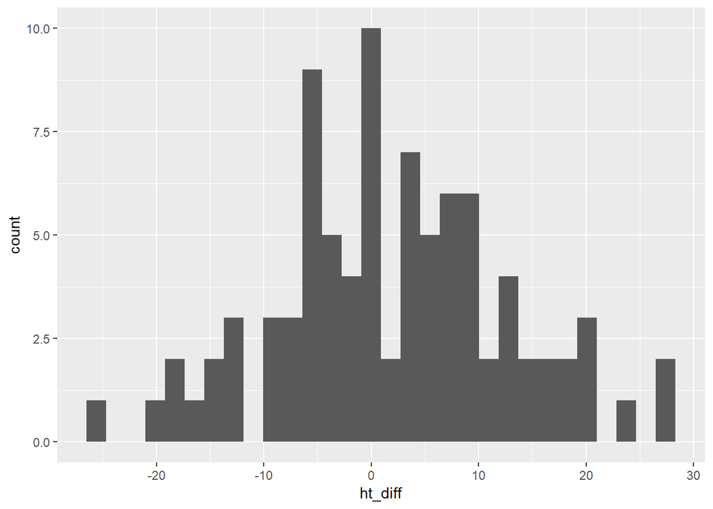

```r
ht_diff_hist_plotty <- ggplot(wim1, aes(ht_diff), na.omit()) + geom_histogram()
suppressWarnings(print(ht_diff_hist_plotty))
```

> 2. Construct a dataset **by_player** with one row per player, recording also the number of wins, ranking points, height and country of the player. Do this in the following steps (i - iv):
1. Construct a dataset w_wim (use **select** and **mutate**), containing for each match the information:
   - name = winner_name
   - points = winner_rank_points
   - ht = winner_ht
   - ioc= winner_ioc
   - A new variable **wins** with a value of **1**

```r
w_wim <- select(wim1, name=winner_name, points=winner_rank_points, ht= winner_ht, ioc= winner_ioc)
w_wim <- mutate(w_wim, wins=1)
str(w_wim)
```

```
## Classes 'tbl_df', 'tbl' and 'data.frame':    127 obs. of  5 variables:
##  $ name  : chr  "Novak Djokovic" "Jarkko Nieminen" "Pierre Hugues Herbert" "Bernard Tomic" ...
##  $ points: int  13845 564 353 1355 1605 715 647 2090 3540 577 ...
##  $ ht    : int  188 185 NA 193 188 190 190 203 198 175 ...
##  $ ioc   : chr  "SRB" "FIN" "FRA" "AUS" ...
##  $ wins  : num  1 1 1 1 1 1 1 1 1 1 ...
```

2. Construct a dataset l_wim (use **select** and **mutate**), containing for each match the information:
   - name = loser_name
   - points = loser_rank_points
   - ht = loser_ht
   - ioc= loser_ioc
   - A new variable **wins** with a value of **0**

```r
l_wim <- select(wim1, name=loser_name, points=loser_rank_points, ht= loser_ht, ioc= loser_ioc)
l_wim <- mutate(l_wim, wins=0)
str(l_wim)
```

```
## Classes 'tbl_df', 'tbl' and 'data.frame':    127 obs. of  5 variables:
##  $ name  : chr  "Philipp Kohlschreiber" "Lleyton Hewitt" "Hyeon Chung" "Jan Lennard Struff" ...
##  $ points: int  1195 465 671 478 723 76 975 539 294 857 ...
##  $ ht    : int  178 180 NA NA NA 180 203 NA NA 190 ...
##  $ ioc   : chr  "GER" "AUS" "KOR" "GER" ...
##  $ wins  : num  0 0 0 0 0 0 0 0 0 0 ...
```

3. Use **rbind** to stick w_wim and l_wim together. Call the result **wl_wim**

```r
wl_wim <- rbind(w_wim, l_wim)
wl_wim
```

```
## # A tibble: 254 x 5
##    name                  points    ht ioc    wins
##    <chr>                  <int> <int> <chr> <dbl>
##  1 Novak Djokovic         13845   188 SRB       1
##  2 Jarkko Nieminen          564   185 FIN       1
##  3 Pierre Hugues Herbert    353    NA FRA       1
##  4 Bernard Tomic           1355   193 AUS       1
##  5 Leonardo Mayer          1605   188 ARG       1
##  6 Marcel Granollers        715   190 ESP       1
##  7 Marsel Ilhan             647   190 TUR       1
##  8 Kevin Anderson          2090   203 RSA       1
##  9 Marin Cilic             3540   198 CRO       1
## 10 Ricardas Berankis        577   175 LTU       1
## # ... with 244 more rows
```

4. Use **group_by** on wl_wim, to group it by name and **summarise** the result of the previous step with:
   - wins=sum(wins)
   - points=points[1]
   - ht=ht[1]
   - ioc=ioc[1]

```r
# used pipes to pass input/output arguments between group_by and summarise functions
by_player <- wl_wim %>% group_by(name) %>% summarise(wins=sum(wins), points=points[1], ht=ht[1], ioc=ioc[1])
head(by_player,3)
```

```
## # A tibble: 3 x 5
##   name              wins points    ht ioc
##   <chr>            <dbl>  <int> <int> <chr>
## 1 Adrian Mannarino     1   1188   183 FRA
## 2 Albert Ramos         1    758   188 ESP
## 3 Alejandro Falla      0    423   185 COL
```

```r
tail(by_player,3)
```

```
## # A tibble: 3 x 5
##   name            wins points    ht ioc
##   <chr>          <dbl>  <int> <int> <chr>
## 1 Vincent Millot     0    234   173 FRA
## 2 Yen Hsun Lu        0    789   180 TPE
## 3 Yuichi Sugita      0    362    NA JPN
```

> 3. Calculate the average height for all players in the tournament. Use ggplot to plot player points versus number of wins.

```r
avg_ht <- mean(by_player$ht,na.rm = TRUE)
avg_ht <- round(avg_ht,2); avg_ht
```

```
## [1] 186.65
```

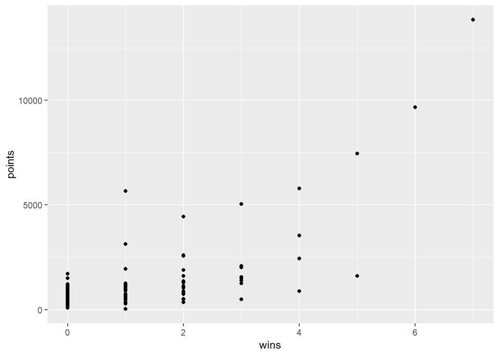

```r
pts_wins_plotty <- ggplot(by_player, aes(wins, points)) + geom_point()
pts_wins_plotty
```

```r
# label points above certain value - not used
# pts_wins_plotty + geom_text(aes(label=ifelse(ht>=avg_ht, ht,'')),hjust=0,vjust=0)
```

> 4. Using the dataset **by_player**, write code to find the names of the tournament winner and the losing finalist. If you did not manage to correctly construct the dataset by_player, do this some other way.

*This solution using the by_player dataset created above assumes a symmetrical draw…*

```r
winner_name <- by_player[which(by_player$wins == max(by_player$wins)),]$name;
winner_name
```

```
## [1] "Novak Djokovic"
```

```r
losing_finalist_name <- by_player[which(by_player$wins == max(by_player$wins)-1),]$name;
losing_finalist_name
```

```
## [1] "Roger Federer"
```

*This solution using the original imported dataset assumes the order of the matches is first to last…*  
* *Used only to confirm the previous result*

```r
tail(select(wim, winner_name, loser_name, score),1)
```

```
## # A tibble: 1 x 3
##   winner_name    loser_name    score
##   <chr>          <chr>         <chr>
## 1 Novak Djokovic Roger Federer 7-6(1) 6-7(10) 6-4 6-3
```

> 5. Calculate the number of wins per country. How many matches were won by Spanish (ESP) players?

```r
wins_per_country <- by_player %>% group_by(ioc) %>% summarise(total_wins_per_country = sum(wins))

esp_wins <- wins_per_country[which(wins_per_country$ioc == "ESP"),]$total_wins_per_country;
esp_wins
```

```
## [1] 11
```

> 6. Draw a barplot showing the number of wins for the top 10 countries, preferrably in decreasing order by wins.

```r
# minus sign sorts descending order
wins_per_country_sorted <- wins_per_country[order(-wins_per_country$total_wins_per_country),];
top_10_countries <- head(wins_per_country_sorted,10);
t(top_10_countries) # transposed just for display purposes
```

```
##                        [,1]  [,2]  [,3]  [,4]  [,5]  [,6]  [,7]  [,8]
## ioc                    "FRA" "ESP" "AUS" "SRB" "SUI" "GBR" "CRO" "USA"
## total_wins_per_country "18"  "11"  "10"  "10"  "10"  " 9"  " 8"  " 7"
##                        [,9]  [,10]
## ioc                    "CAN" "CZE"
## total_wins_per_country " 6"  " 5"
```

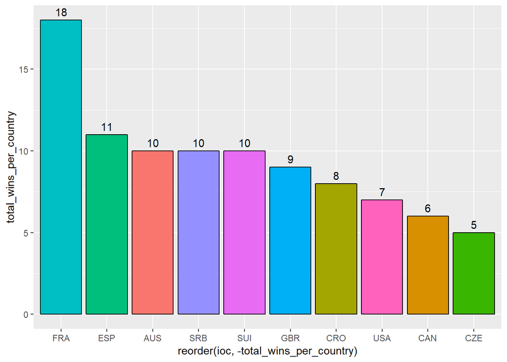

```r
top_10_countries_plotty <- ggplot(top_10_countries, aes(x = reorder(ioc, -total_wins_per_country),
                                      y = total_wins_per_country, fill = ioc)) +
  geom_col(colour="black") + geom_text(aes(label = total_wins_per_country), hjust=0.5, vjust=-0.5) +
  theme(legend.position="none"); top_10_countries_plotty
```

## Question 2

**For the University ranking data from the midterm, first convert appropriate variables to numeric.** **Then answer these questions using dplyr tools and ggplot, in all cases except part (b).**

> 1. Summarise the Location (countries) of the universities with counts. Using ggplot, draw a barplot of these location counts.

```r
d <- read.csv("https://tinyurl.com/y8e8cb9t", stringsAsFactors = FALSE);
str(d); # check structure
```

```
## 'data.frame':    40 obs. of  10 variables:
##  $ World.Rank           : int  1 2 3 4 5 6 7 8 9 10 ...
##  $ Institution          : chr  "Harvard University" "Stanford University" "Massachusetts Institute of Technology" "University of Cambridge" ...
##  $ Location             : chr  "USA" "USA" "USA" "United Kingdom" ...
##  $ National.Rank        : int  1 2 3 1 2 4 5 6 7 8 ...
##  $ QualityÂ.of.Education: chr  "1" "9" "3" "2" ...
##  $ Publications         : int  1 5 15 11 7 13 10 17 72 24 ...
##  $ Influence            : int  1 3 2 6 12 13 4 16 25 15 ...
##  $ Citations            : int  1 3 2 12 7 11 4 12 24 25 ...
##  $ Broad.Impact         : int  1 4 2 13 9 12 7 22 33 22 ...
##  $ Score                : num  100 98.7 97.5 96.8 96.5 ...
```

```r
d$QualityÂ.of.Education <- as.numeric(d$QualityÂ.of.Education)
str(d); # confirm conversion of appropriate variables to numeric
```

```
## 'data.frame':    40 obs. of  10 variables:
##  $ World.Rank           : int  1 2 3 4 5 6 7 8 9 10 ...
##  $ Institution          : chr  "Harvard University" "Stanford University" "Massachusetts Institute of Technology" "University of Cambridge" ...
##  $ Location             : chr  "USA" "USA" "USA" "United Kingdom" ...
##  $ National.Rank        : int  1 2 3 1 2 4 5 6 7 8 ...
##  $ QualityÂ.of.Education: num  1 9 3 2 7 13 5 11 4 12 ...
##  $ Publications         : int  1 5 15 11 7 13 10 17 72 24 ...
##  $ Influence            : int  1 3 2 6 12 13 4 16 25 15 ...
##  $ Citations            : int  1 3 2 12 7 11 4 12 24 25 ...
##  $ Broad.Impact         : int  1 4 2 13 9 12 7 22 33 22 ...
##  $ Score                : num  100 98.7 97.5 96.8 96.5 ...
```

```r
univs_per_country <- count(d, Location); univs_per_country;
```

```
## # A tibble: 8 x 2
##   Location           n
##   <chr>          <int>
## 1 Canada             1
## 2 France             2
## 3 Israel             2
## 4 Japan              4
## 5 South Korea        1
## 6 Switzerland        1
## 7 United Kingdom     4
## 8 USA               25
```

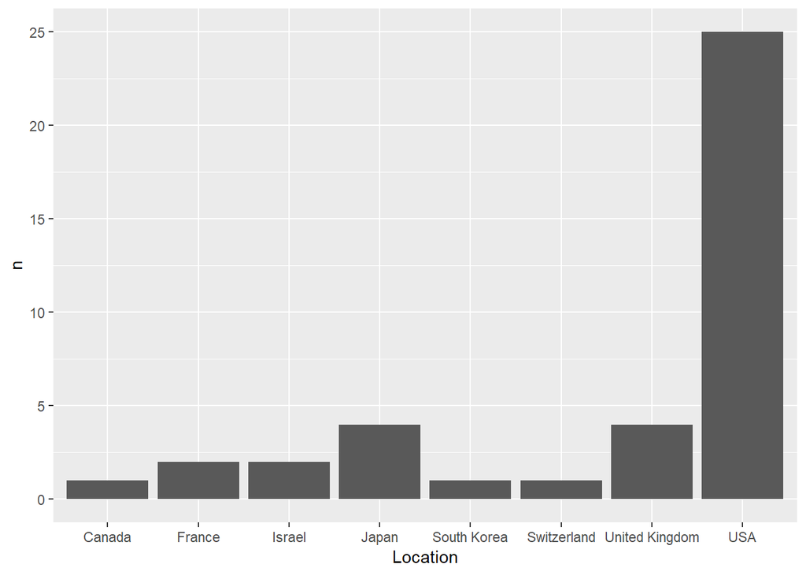

```r
univs_per_ctry_plotty <- ggplot(univs_per_country, aes(x = Location, y = n)) + geom_col();
univs_per_ctry_plotty
```

> 2. Redraw the barplot, with bars in decreasing order. Use fct_reorder.

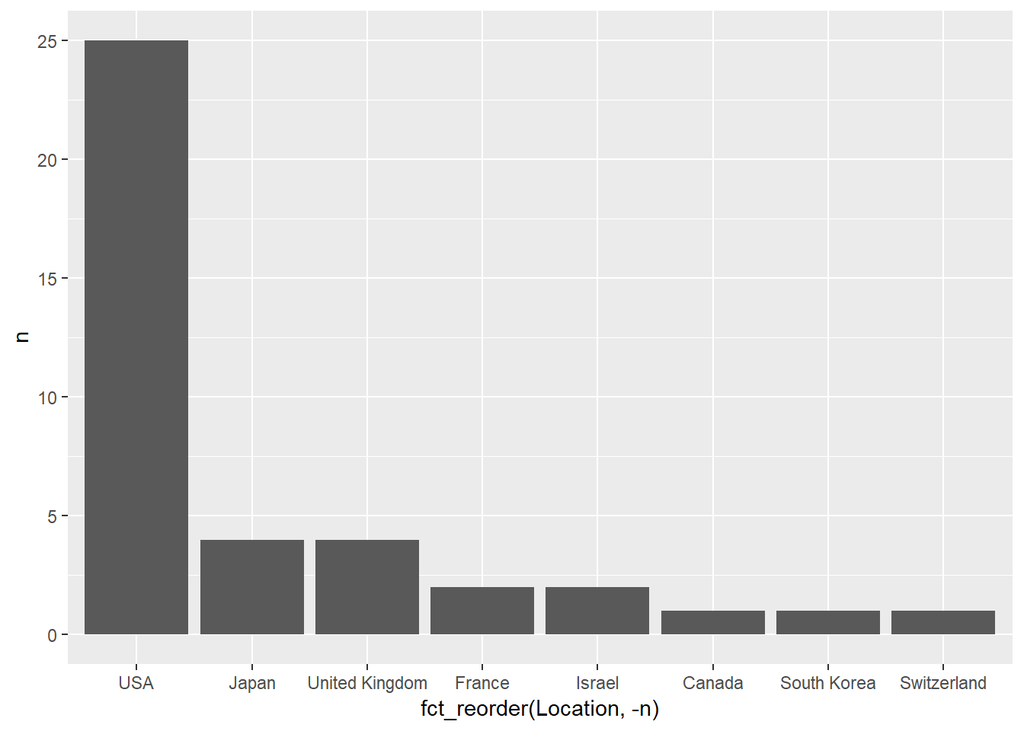

```r
univs_per_ctry_plotty_decreasing <-
  ggplot(univs_per_country, aes(x = fct_reorder(Location, -n), y = n)) +
  geom_col();

univs_per_ctry_plotty_decreasing
```

> 3. Write a function called top5 that counts the number of values in 1, 2, …5 in a numeric vector, ignoring NAs. Use %in% .

```r
top5 <- function(input_vector){
  counter <- 0;
  for (i in 1:length(input_vector)){
    if (input_vector[i] %in% 1:5){
      counter <- counter + 1;
    }
  }
  counter
}
```

*Check that the top5 function gives the correct answer on vectors below:*  
* x1 <- c(NA,10:1)  
* x2 <- rnorm(8)  
* x3 <- c(6,2,8,9,-1,0,4)

```r
x1 <- c(NA,10:1); top5(x1);
```

```
## [1] 5
```

```r
x2 <- rnorm(8); top5(x2);
```

```
## [1] 0
```

```r
x3 <- c(6,2,8,9,-1,0,4); top5(x3);
```

```
## [1] 2
```

> 4. Use top5 to calculate for each university, how many of the categories Quality.of.Education, Publications, Influence, Citations, Broad.Impact accorded them a top 5 ranking. Add this information to your dataset. Use base R for your answer.

```r
QOE_col <- which(colnames(d)=="QualityÂ.of.Education") # get col number
IMP_col <- which(colnames(d)=="Broad.Impact") # get col number
for (i in 1:nrow(d)){
  d$top5count[i] <- top5(d[i, QOE_col:IMP_col]) # create new col and set value
}
d[1:10, c(which(colnames(d)=="Institution"),ncol(d))] # check result from above
```

```
##                              Institution top5count
## 1                     Harvard University         5
## 2                    Stanford University         4
## 3  Massachusetts Institute of Technology         4
## 4                University of Cambridge         1
## 5                   University of Oxford         0
## 6                    Columbia University         0
## 7     University of California, Berkeley         3
## 8                  University of Chicago         0
## 9                   Princeton University         1
## 10                    Cornell University         0
```

> 5. Here is a dplyr answer to the previous question. Explain how it works. Write code which confirms the columns tc and topcount are identical. Here the base R solution is simpler, in my opinion. Can anyone supply a simpler and better dplyr-based answer?

```r
sel <- c("QualityÂ.of.Education","Publications","Influence","Citations","Broad.Impact")
str(sel)
```

```
##  chr [1:5] "QualityÂ.of.Education" "Publications" "Influence" ...
```

```r
d1 <- d %>% mutate_at(sel, '<=', 5) %>% select(one_of(sel)) %>% mutate(tc = rowSums(., na.rm=F))
d1[1:10, ncol(d1)]
```

```
##  [1] 5 4 4 1 0 0 3 0 1 0
```

**d1 <- d %>%**  
- assigns output to dataframe object d1, ‘pipes’ copy of dataframe object into proceeding function

**mutate_at(sel, ‘<=’, 5…** - uses temp ‘sel’ to identify/hold cols satisfying condition ‘<=’ 5

**select(one_of(sel)) %>%**  
- passes cols previously identified to next function without specifying actual col names

**mutate(tc =…**  
- create new col in input dataframe (‘tc’) to hold sum of row val

```r
#d2 <- for(i in 1:nrow(d)){ mutate(d, tc2[i] <- sum(d[i, 5:9])) }#d2[1:5,"tc2"]
```

```r
d <- mutate(d, Continent = ifelse((d$Location == "USA")|(d$Location =="Canada"), "NorthAmerica", ifelse((d$Location == "Japan")|(d$Location=="South Korea"),"Asia", "Europe" )));
d[1:5, c(which(colnames(d)=="Institution"),ncol(d))]
```

```
##                             Institution    Continent
## 1                    Harvard University NorthAmerica
## 2                   Stanford University NorthAmerica
## 3 Massachusetts Institute of Technology NorthAmerica
## 4               University of Cambridge       Europe
## 5                  University of Oxford       Europe
```

> 8. Plot the Citations versus the Broad.Impact rankings, using different colours to distinguish the continents.

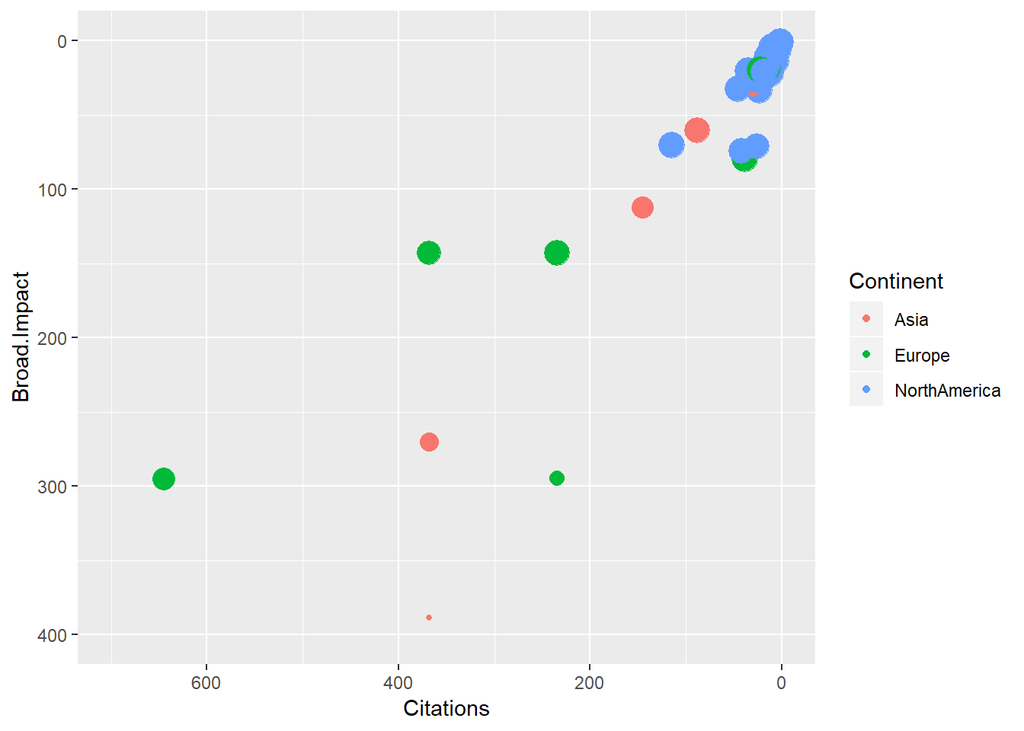

```r
# using 'Influence' to control point size, minus sign to invert i.e. 1 = most, 40 = least
univs_cita_bro_plotty <- ggplot(d, aes(Citations, Broad.Impact, colour = Continent)) +
  geom_jitter(aes(size = -Influence)) + guides(size=FALSE); univs_cita_bro_plotty +
  scale_y_reverse(lim=c(400,0)) + scale_x_reverse(lim=c(700,0))
```

```r
# less cluttered vis.
# univs_cita_bro_plotty <- ggplot(d, aes(sqrt(Citations), Broad.Impact, colour = Continent)) +
#   geom_jitter(aes(size = -Influence)) + guides(size=FALSE); univs_cita_bro_plotty +
#   scale_y_reverse(lim=c(400,0))
```